# Project Business Statistics: E-news Express

## Define Problem Statement and Objectives

## Import all the necessary libraries

```python
# Installing the libraries with the specified version.
!pip install numpy==1.25.2 pandas==1.5.3 matplotlib==3.7.1 seaborn==0.13.1 scipy==1.11.4 -q --user
```

[output not shown]

[output cut: 66 more lines]

[output not shown]

**Note**: *After running the above cell, kindly restart the notebook kernel and run all cells sequentially from the start again.*

```python
# importing libraries for arrays and data manipulation/analysis
import numpy as np
import pandas as pd

import matplotlib.pyplot as plt # library for plots/visualizations
import seaborn as sns # library for visualizations

from scipy import stats # library for probability distributions and statistical functions
```

## Reading the Data into a DataFrame

```python
# Loading the dataset
from google.colab import drive
drive.mount('/content/drive')

path = "/content/drive/MyDrive/Content/abtest.csv"
data = pd.read_csv(path)

# Creating a copy of data so it won't change original data
df= data.copy()
```

## Explore the dataset and extract insights using Exploratory Data Analysis

- Data Overview
  - Viewing the first and last few rows of the dataset
  - Checking the shape of the dataset
  - Getting the statistical summary for the variables
- Check for missing values
- Check for duplicates

```python
# Viewing the first few rows of the dataset
df.head()
```

|  | user_id | group | landing_page | time_spent_on_the_page | converted | language_preferred |
| --- | --- | --- | --- | --- | --- | --- |
| 0 | 546592 | control | old | 3.48 | no | Spanish |
| 1 | 546468 | treatment | new | 7.13 | yes | English |
| 2 | 546462 | treatment | new | 4.40 | no | Spanish |
| 3 | 546567 | control | old | 3.02 | no | French |
| 4 | 546459 | treatment | new | 4.75 | yes | Spanish |

```python
# Viewing the last few rows of the dataset
df.tail()
```

|  | user_id | group | landing_page | time_spent_on_the_page | converted | language_preferred |
| --- | --- | --- | --- | --- | --- | --- |
| 95 | 546446 | treatment | new | 5.15 | no | Spanish |
| 96 | 546544 | control | old | 6.52 | yes | English |
| 97 | 546472 | treatment | new | 7.07 | yes | Spanish |
| 98 | 546481 | treatment | new | 6.20 | yes | Spanish |
| 99 | 546483 | treatment | new | 5.86 | yes | English |

```python
# Checking the shape of the data
print("The dataset has", df.shape[0], "rows and", df.shape[1], "columns.")
```

```
The dataset has 100 rows and 6 columns.
```

```python
# Getting the statistical summary for the variables
df.describe()
```

|  | user_id | time_spent_on_the_page |
| --- | --- | --- |
| count | 100.000000 | 100.000000 |
| mean | 546517.000000 | 5.377800 |
| std | 52.295779 | 2.378166 |
| min | 546443.000000 | 0.190000 |
| 25% | 546467.750000 | 3.880000 |
| 50% | 546492.500000 | 5.415000 |
| 75% | 546567.250000 | 7.022500 |
| max | 546592.000000 | 10.710000 |

```python
# Checking the data type of the columns
df.info()
```

```
<class 'pandas.core.frame.DataFrame'>
RangeIndex: 100 entries, 0 to 99
Data columns (total 6 columns):
 #   Column                  Non-Null Count  Dtype
---  ------                  --------------  -----
 0   user_id                 100 non-null    int64
 1   group                   100 non-null    object
 2   landing_page            100 non-null    object
 3   time_spent_on_the_page  100 non-null    float64
 4   converted               100 non-null    object
 5   language_preferred      100 non-null    object
dtypes: float64(1), int64(1), object(4)
memory usage: 4.8+ KB
```

```python
# Checking for missing values in the dataset
df.isnull().sum()
```

|  | 0 |
| --- | --- |
| user_id | 0 |
| group | 0 |
| landing_page | 0 |
| time_spent_on_the_page | 0 |
| converted | 0 |
| language_preferred | 0 |

**dtype:** int64

```python
# Checking for duplicate entries in the dataset
df.duplicated().sum()
```

```
np.int64(0)
```

### Univariate Analysis

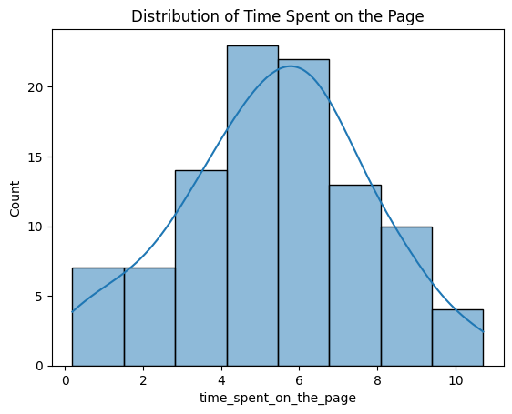

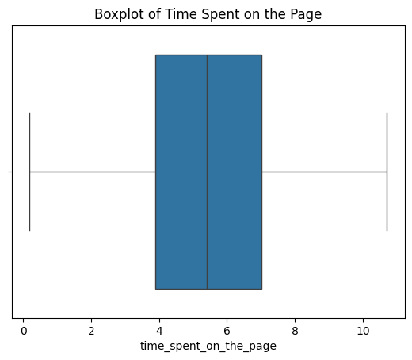

```python
# Analyzing Time Spent on the Page with histoplot and boxplot
sns.histplot(data=df, x='time_spent_on_the_page', kde=True)
plt.title("Distribution of Time Spent on the Page")
plt.show()
sns.boxplot(data=df, x='time_spent_on_the_page')
plt.title("Boxplot of Time Spent on the Page")
plt.show()
```

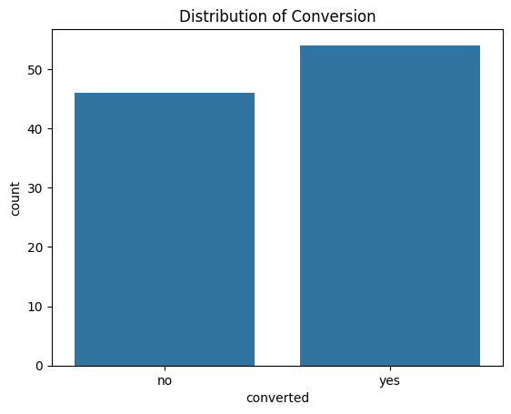

```python
# Observing number of users converted
sns.countplot(data=df, x='converted')
plt.title("Distribution of Conversion")
plt.show()
```

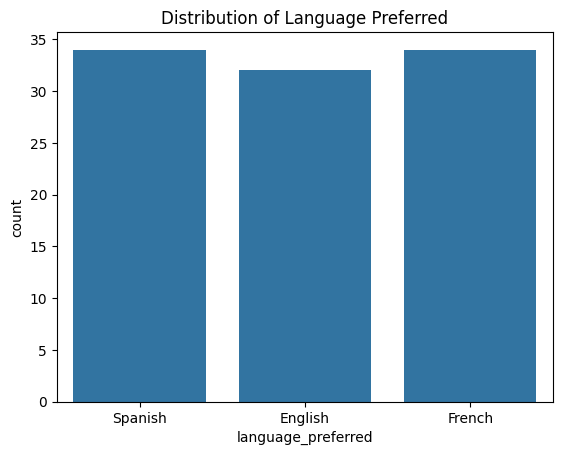

```python
# Observing number of users by language preferred
sns.countplot(data=df, x='language_preferred')
plt.title("Distribution of Language Preferred")
plt.show()
```

### Bivariate Analysis

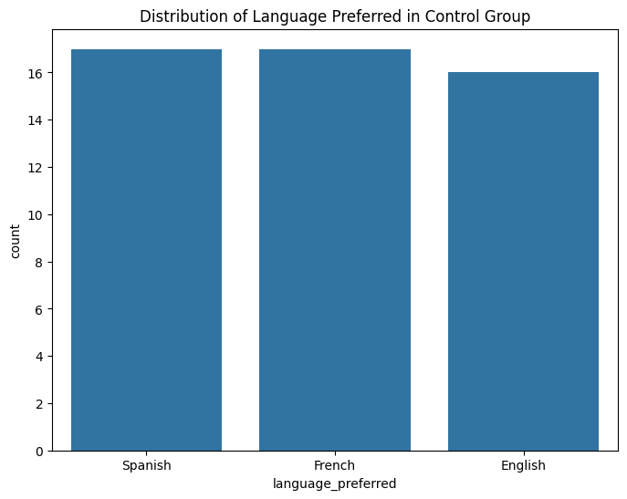

```python
# Observing Language Preferred of control group
plt.figure(figsize=(8,6))
sns.countplot(data=df[df['group']=='control'], x='language_preferred')
plt.title("Distribution of Language Preferred in Control Group")
plt.show()
```

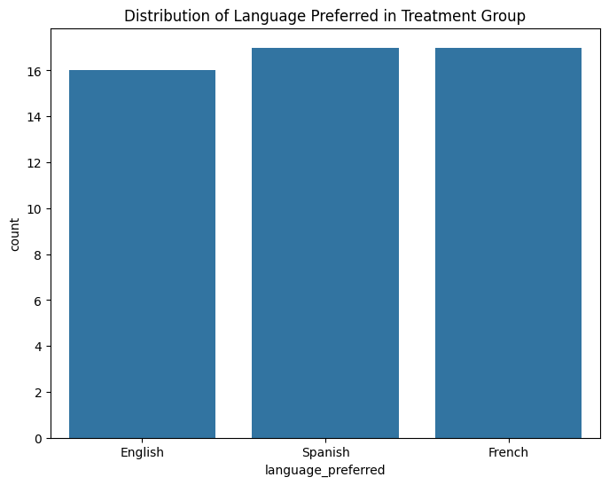

```python
# Observing Language Preferred in treatment group
plt.figure(figsize=(8,6))
sns.countplot(data=df[df['group']=='treatment'], x='language_preferred')
plt.title("Distribution of Language Preferred in Treatment Group")
plt.show()
```

## 1. Do the users spend more time on the new landing page than the existing landing page?

### Perform Visual Analysis

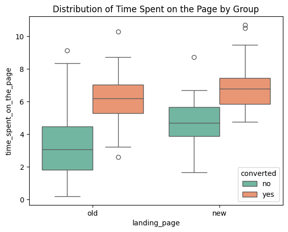

```python
# Creating boxplot of time spent on page by landing page and group
sns.boxplot(data=df, x='landing_page', y='time_spent_on_the_page', hue='converted', palette='Set2')
plt.title("Distribution of Time Spent on the Page by Group")
plt.show()
```

### Step 1: Define the null and alternate hypotheses

H0: The average time spent on the new landing page is equal to the average time spent on the existing landing page

HA: The average time spent on the new landing page is not equal to the average time spent on the existing page.

### Step 2: Select Appropriate test

Two-tailed t-test

### Step 3: Decide the significance level

Significance level 0.05

### Step 4: Collect and prepare data

```python
from scipy.stats import ttest_ind # Calling independent samples t-test function from scipy.stats

# Filtering dataset into two groups based on separate variables
new = df[df['landing_page'] == 'new']['time_spent_on_the_page']
old = df[df['landing_page'] == 'old']['time_spent_on_the_page']
```

### Step 5: Calculate the p-value

```python
# Running the t-test, calculating p-value
t_stat, p_value = ttest_ind(new, old, equal_var=False)
print("t-statistic:", t_stat)
print("p-value:", p_value)
```

```
t-statistic: 3.7867702694199856
p-value: 0.0002784762450333098
```

### Step 6: Compare the p-value with $\alpha$

0.0002 < 0.05

### Step 7: Draw inference

Since the p-value is less than 0.05, we reject the null hypothesis that the average time spent on the existing landing page is equal to the average time spent on the new landing page. Because the t-statistic is greater than 0, we can say that the average time spent on the new page is greater than the average time spent on the existing page with statistical significance of 0.05.

**A similar approach can be followed to answer the other questions.**

## 2. Is the conversion rate (the proportion of users who visit the landing page and get converted) for the new page greater than the conversion rate for the old page?

**Perform Visual Analysis**

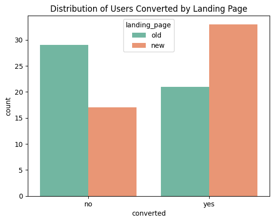

```python
# Creating countplot of users converted by landing page
sns.countplot(data = df, x ='converted', hue = 'landing_page', palette = 'Set2')
plt.title("Distribution of Users Converted by Landing Page")
plt.show()
```

**Define the null and alternative hypotheses** H0:The conversion rate for the new page equals the conversion rate for the old page. HA:The conversion rate for the new page is not equal to the old page.

**Select the appropriate test** Two-proprtion z-test

**Decide significance level** Significance level 0.05

**Collect and prepare data**

```python
# Create crosstab of landing_page vs converted
conversion_table = pd.crosstab(df['landing_page'], df['converted'])
print(conversion_table)
```

```
converted     no  yes
landing_page
new           17   33
old           29   21
```

```python
# Extracting counts for each category
converted_old = conversion_table.loc['old', 'yes'].sum()
total_old = conversion_table.loc['old'].sum()

converted_new = conversion_table.loc['new', 'yes'].sum()
total_new = conversion_table.loc['new'].sum()
```

**Calculate p-value**

```python
# Importing two-proportion z-test
from statsmodels.stats.proportion import proportions_ztest

# Assigning variables
count = [converted_new, converted_old]
nobs = [total_new, total_old]

# Running test and calculating p-value
stat, p_value = proportions_ztest(count, nobs)
print('z-statistic:', stat)
print('p-value:', p_value)
```

```
z-statistic: 2.4077170617153842
p-value: 0.016052616408112556
```

**Compare the p-value with $\alpha$**

0.016 < 0.05

**Draw inference**

Because 0.016 is less than 0.05, we can reject the null hypothesis that the conversion rates for the new and old pages are the same. A z-statistic score of 2.4(greater than 0) indicates that the new page has a significantly higher conversion rate compared to the old page.

## 3. Does the conversion status depend on the preferred language?

**Perform Visual Analysis**

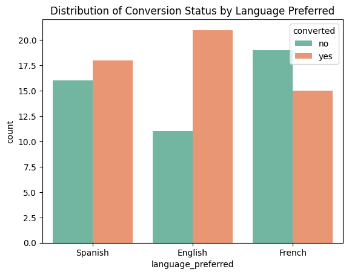

```python
sns.countplot(data=df, x='language_preferred', hue='converted', palette='Set2')
plt.title("Distribution of Conversion Status by Language Preferred")
plt.show()
```

**Define null and alternate hypotheses**

H0: Conversion status does not depend on preferred language.

HA: Conversion status is dependent on preferred language.

**Select appropriate test** Chi-square test of independence

**Decide significance level** 0.05

**Collect and prepare data**

```python
# Importing chi2 test
from scipy.stats import chi2_contingency

# Creating a contingency table
contingency_table = pd.crosstab(df['language_preferred'], df['converted'])
print(contingency_table)
```

```
converted           no  yes
language_preferred
English             11   21
French              19   15
Spanish             16   18
```

**Calculate p-value**

```python
# Running chi-square test of independence
chi2, p, dof, expected = chi2_contingency(contingency_table)
print('chi-square statistic:', chi2)
print('p-value:', p)
```

```
chi-square statistic: 3.0930306905370832
p-value: 0.2129888748754345
```

**Compare the p-value with $\alpha$**

0.21 > 0.05

**Draw inference** Because the p-value 0.21 is greater than 0.05, we fail to reject the null hypothesis. We can conclude that conversion status is not dependent on preferred language with a statistical significance of 0.05.

## 4. Is the time spent on the new page same for the different language users?

**Peform Visual Analysis**

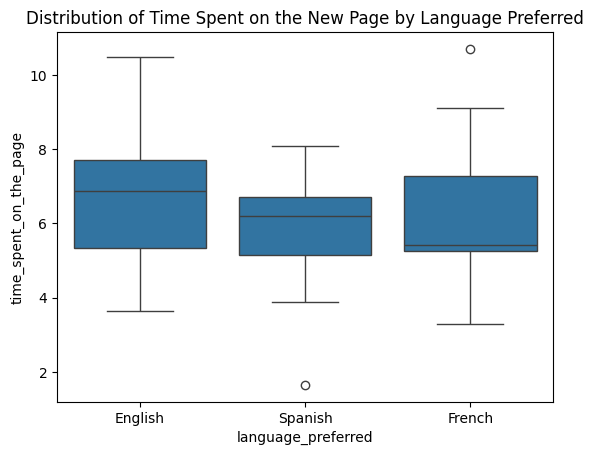

```python
# Importing libraries
import seaborn as sns
import matplotlib.pyplot as plt

# Assigning subset variable
new_page= df[df['landing_page']=='new']

# Creating boxplot of time spent on the new page by language preferred
sns.boxplot(data= new_page, x='language_preferred', y ='time_spent_on_the_page')
plt.title("Distribution of Time Spent on the New Page by Language Preferred")
plt.show()
```

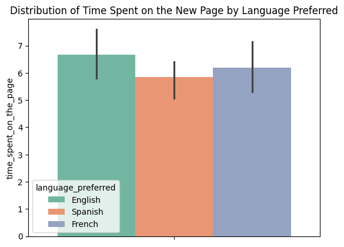

```python
# Creating a barplot for Time spent on the New Page by Language Preferred with a confidence interval 95% error bar
sns.barplot(data= new_page, hue='language_preferred', y='time_spent_on_the_page', errorbar=('ci',95), palette='Set2')
plt.title("Distribution of Time Spent on the New Page by Language Preferred")
plt.show()
```

**Define the null and alternate hypotheses** H0: The average time spent on the new landing page is the same for all languages preferred. HA: The average time spent on the new landing page differs for at least one language preferred.

**Select appropriate test** ANOVA

**Decide the significance level** Significance level 0.05

**Collect and prepare data**

```python
# Importing levene function of Scipy for ANOVA
from scipy.stats import levene
```

**Calculate the p-value**

```python
# Calculating p-value
statistic, p_value= levene(new_page[new_page['language_preferred']=='English']['time_spent_on_the_page']
                           ,new_page[new_page['language_preferred']=='French']['time_spent_on_the_page']
                           ,new_page[new_page['language_preferred']=='Spanish']['time_spent_on_the_page'])
# Print p-value
print('p-value:', p_value)
```

```
p-value: 0.46711357711340173
```

**Compare the p-value with $\alpha$**

0.46 > 0.05.

**Performing Multiple Comparison test** To identify which group differs from the others the null hypothesis is:

> $𝐻_0: 𝜇_1=𝜇_2 \text{ and } 𝜇_1=𝜇_3 \text{ and } 𝜇_2=𝜇_3$

and the alternative hypothesis is:

> $𝐻_a: 𝜇_1\neq𝜇_2 \text{ or } 𝜇_1\neq𝜇_3 \text{ or } 𝜇_2\neq𝜇_3$

```python
# Importing the Tukey HSD function
from statsmodels.stats.multicomp import pairwise_tukeyhsd

# Perform multiple pairwise comparison (Tukey HSD)
multiple_comp= pairwise_tukeyhsd(endog=new_page['time_spent_on_the_page'],
                                 groups=new_page['language_preferred'],
                                 alpha=0.05)

# Print the results
print(multiple_comp)
```

```
 Multiple Comparison of Means - Tukey HSD, FWER=0.05
=====================================================
 group1  group2 meandiff p-adj   lower  upper  reject
-----------------------------------------------------
English  French  -0.4673 0.7434 -2.0035  1.069  False
English Spanish  -0.8285 0.3995 -2.3647 0.7078  False
 French Spanish  -0.3612 0.8326  -1.874 1.1516  False
-----------------------------------------------------
```

Because the Tukey HSD post-hoc test revealed p-values all exceeding 0.05, we can conclude no statistically significant differences in average time spent on the new landing page between the languages preferred by users. This indicates that language preference did not significantly affect time spent on the new page.

## Conclusion and Business Recommendations

The E-News Express sought to understand if the design of their new landing page was effective in gathering new subscribers.

We ran a two-tailed t-test to find out if the average time spent on the new page was significantly different from average the time spent on the existing page. We found the average time spent on the new page to be greater than the existing page with a statistical significance of 0.05.

We conducted a two-proportion z-test and found out if the conversion rate for the new page was significantly higher than that of the existing page with a statistical significance of 0.05.

We used the chi-square test of independence to determine if conversion status depended on preferred language and found that it does not with a statistical significance of 0.05.

Statistical evidence strongly suggests that the new landing page is effective in gathering new subscribers to E-News Express. While engagement levels seem to differ by language, it is not enough to suggest a change in their current approach to different language speakers.

If at all, I might suggest conducting a survey to see if there is another language that could be included in order to increase current engagement levels and customer base.

```python
!jupyter nbconvert --to html ENews_Express_Full_Code_ARodriguez.ipynb
```

[output not shown]

[output cut: 136 more lines]

[output not shown]